# 16/17 DPH101 final B. Comparing Two Means

dizhen

2020.1.7

## B. Comparing Two Means

### Step1. Data

```r
DRUG_A <- c(3.14,3.45,3.32,3.45,3.09,3.27,3.64,2.5,2.64,3.32,3.73,3.14,3.09,2.59,3.91)
CON <- c(2.91,3.05,2.45,3.73,2.41,3,2.64,2.59,2.82,3.23,3.18,3.14,2.55,1.91,3.09)
```

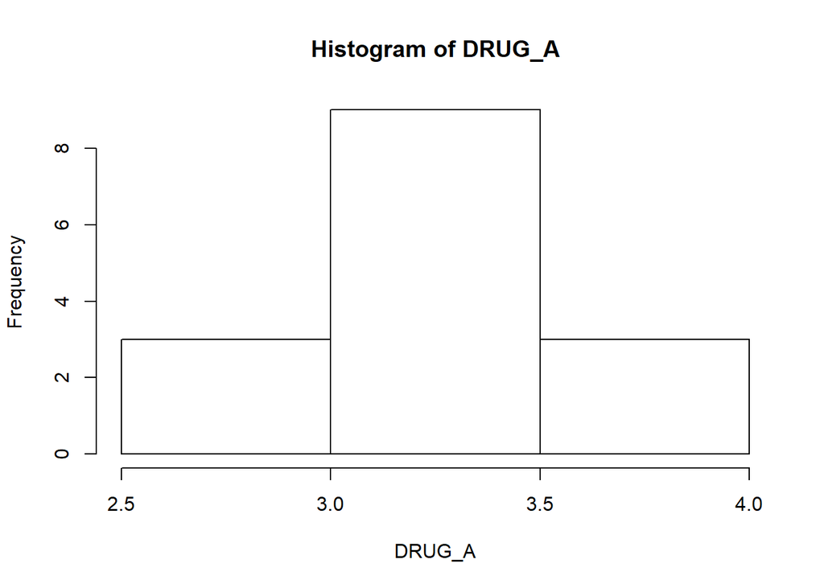

```r
hist(DRUG_A)
```

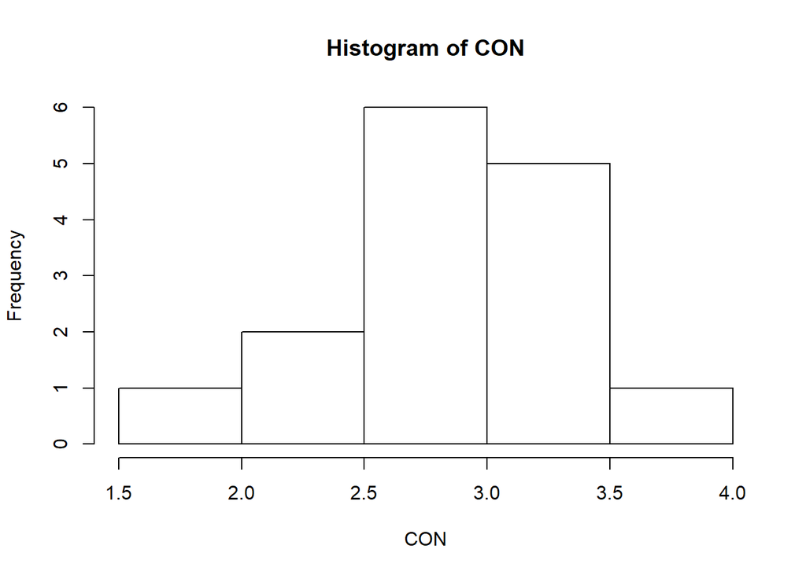

```r
hist(CON)
```

```r
treatment <- c(rep("DRUG_A", length(DRUG_A)))
weight <- DRUG_A
df1 <- data.frame(treatment, weight)

treatment <- c(rep("CON", length(CON)))
weight <- CON
df2 <- data.frame(treatment, weight)

mydf <- rbind.data.frame(df1,df2)
mydf
```

```
##    treatment weight
## 1     DRUG_A   3.14
## 2     DRUG_A   3.45
## 3     DRUG_A   3.32
## 4     DRUG_A   3.45
## 5     DRUG_A   3.09
## 6     DRUG_A   3.27
## 7     DRUG_A   3.64
## 8     DRUG_A   2.50
## 9     DRUG_A   2.64
## 10    DRUG_A   3.32
## 11    DRUG_A   3.73
## 12    DRUG_A   3.14
## 13    DRUG_A   3.09
## 14    DRUG_A   2.59
```

[output cut: 16 more lines]

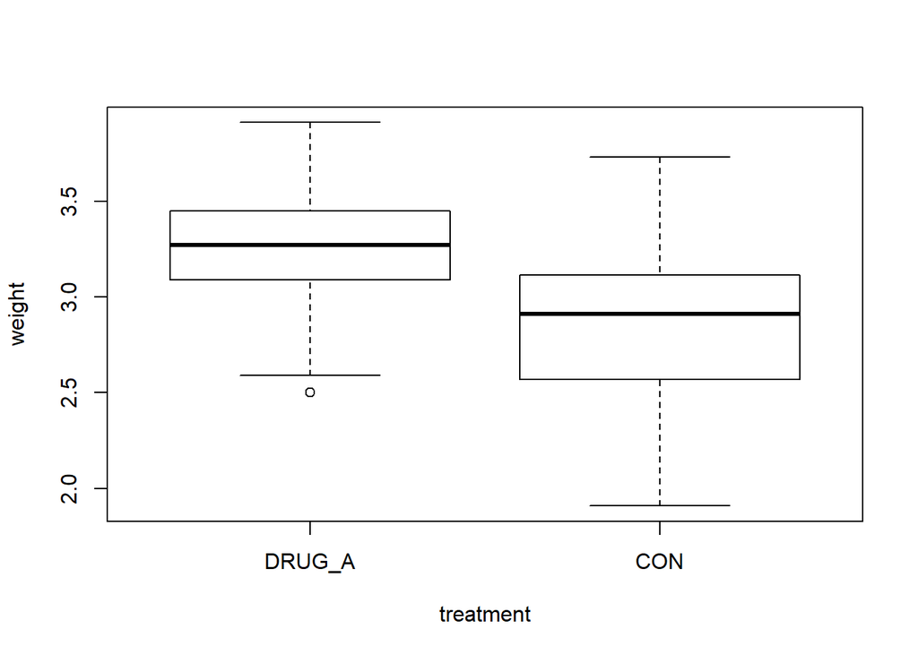

```r
boxplot(weight ~ treatment, data = mydf)
```

Conclusion. There was no evidence of non-normality (boxplots not grossly asymmetrical) or unequal variance (boxplots very similar size and variances very similar). Hence, the simple, studentized (pooled variances) t-test is likely to be reliable.

### Step2. Assumption

1. Both samples are simple random samples.
2. Two samples are independent, they are not matched or paired in any way.
3. Both sample sizes are normally distributed.
4. Both population standard deviations $\sigma_1$ and $\sigma_2$ are unknown.

### Step3. Hypothesis

Alternative hypothesis: The mean of birthweights after taking drug A $\bar{x_1}$ is higher than it of control $\bar{x_2}$.
$$H_0: \bar{x_1} \leqslant \bar{x_2}\\
H_A: \bar{x_1} > \bar{x_2}$$

### Step4. Test Statistic

We consider the population variances are equal, then we can pool the sample variances:
$$s_p^2 = \frac{s_1^2 (n_1 - 1) + s_2^2 (n_2 - 1)}{n_1 + n_2 - 2}$$
$$t = \frac{\bar{x_1}-\bar{x_2}}{\sqrt{ \frac{s_p^2}{n_1} + \frac{s_p^2}{n_2} }}$$
$$\nu = n_1 + n_2 -2$$

### Step5. Distribution of the Test Statistic

As the sampling distribution of t is the standard normal distribution, so:
$$t \sim N(0,1)$$

### Step6. Decision Rule

This is an independent two-sample t-test with equal variance. The significant level $\alpha = 0.05$, so that critical value $t_0 = 1.64$. This determines that the critical region is the area where $t_0 > 1.64$.

```r
alpha <- 0.05
t_alpha <- qnorm(1 - alpha)
t_alpha
```

```
## [1] 1.644854
```

### Step7. Calculation of test statistic

Perform an independent two-sample t-test with equal variance. $\alpha = 0.05$.

The t test statistic:
$$t = \frac{\bar{x_1}-\bar{x_2}}{\sqrt{ \frac{s_p^2}{n_1} + \frac{s_p^2}{n_2} }} = 2.407$$

This consists of calculation in step4 and the result $t = 2.407$ is compared to the critical value calculated in step6. t value 2.407 is more than critical value $t_0 = 1.64$. 95% Confidence interval of the difference in means is (0.06, 0.69), we are 95% confident that the population mean is between 0.06 and 0.69 because on repeated sampling, 95% of all intervals created in this manner would include the population mean.

```r
# this is for calculating confidence interval, p-value is not correct
t.test(weight ~ treatment,
       data = mydf,
       alternative = "two.sided",
       var.equal = T)
```

```
##
##  Two Sample t-test
##
## data:  weight by treatment
## t = 2.4074, df = 28, p-value = 0.0229
## alternative hypothesis: true difference in means is not equal to 0
## 95 percent confidence interval:
##  0.05547204 0.68852796
## sample estimates:
## mean in group DRUG_A    mean in group CON
##             3.218667             2.846667
```

```r
# this is for calculating p-value, confidence interval is not correct.
t.test(weight ~ treatment,
       data = mydf,
       alternative = "greater",
       var.equal = T)
```

```
##
##  Two Sample t-test
##
## data:  weight by treatment
## t = 2.4074, df = 28, p-value = 0.01145
## alternative hypothesis: true difference in means is greater than 0
## 95 percent confidence interval:
##  0.1091345       Inf
## sample estimates:
## mean in group DRUG_A    mean in group CON
##             3.218667             2.846667
```

### Step8. Statistical decision

Since the t value falls in the rejection region, we rejected null hypothesis.

### Step10. P-value

P-value is 0.011, which is less than 0.05. 1. If the study is repeated many times, there is 1.1% chance of observing the mean of birthweights after taking drug A $\bar{x_1}$ is higher than control $\bar{x_2}$. 2. There is a 1.1% chance of observing a same or greater mean birthweight after taking drug than control from random sampling than observed.